# Themes in ggplot

The package `ggthemes` has several predefined themes you can customize a ggplot graph, chart, or map.

# Required packages

This example uses the following packages:

```r
library(tidyverse)
library(ggthemes)
```

# Sample data

I have a dataframe called `countries` with national boundaries in Africa. I can use `ggplot()` and `geom_sf()` to make a quick chloropleth map with variations in color to represent the estimated GDP.

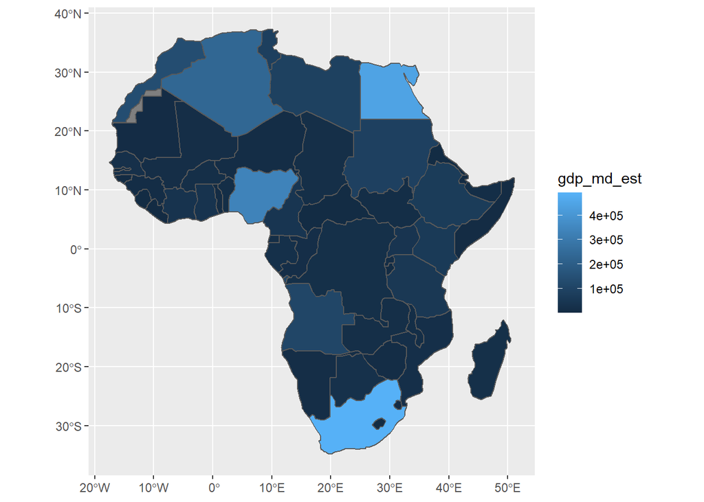

```r
gdp_map <- ggplot(countries) +
  geom_sf(aes(fill = gdp_md_est))

gdp_map
```

# Apply a theme

The map above uses the default theme for ggplot maps. It has a gray background with white gridlines, and a legend on the righthand side of the plot. The `ggplot2` package comes with other options for themes, such as `theme_bw()`:

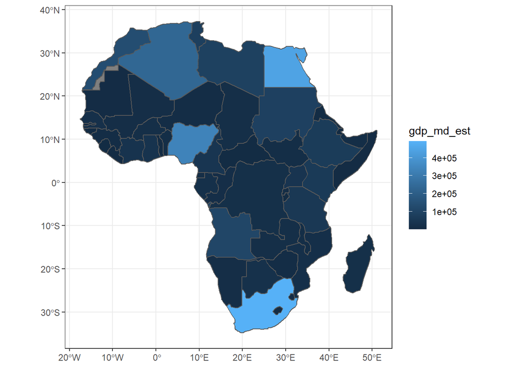

```r
gdp_map +
  theme_bw()
```

`theme_dark()`:

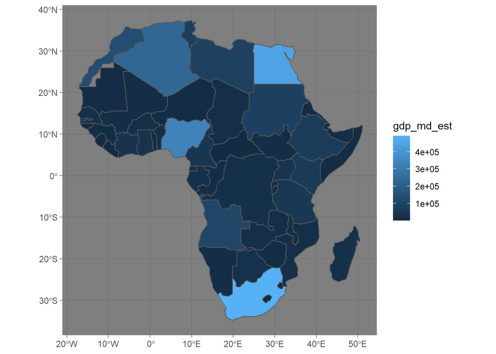

```r
gdp_map +
  theme_dark()
```

Or `theme_minimal()`:

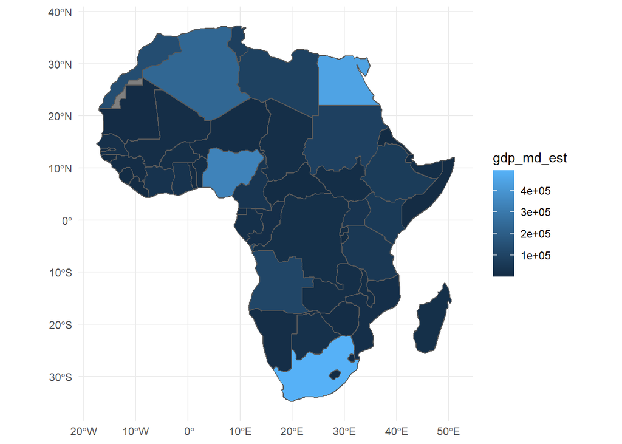

```r
gdp_map +
  theme_minimal()
```

For the most part, these themes were designed with scatterplots in mind. More often than not, for a map, you just want a blank background with no gridlines or axis labels. You can get that with `theme_void()`:

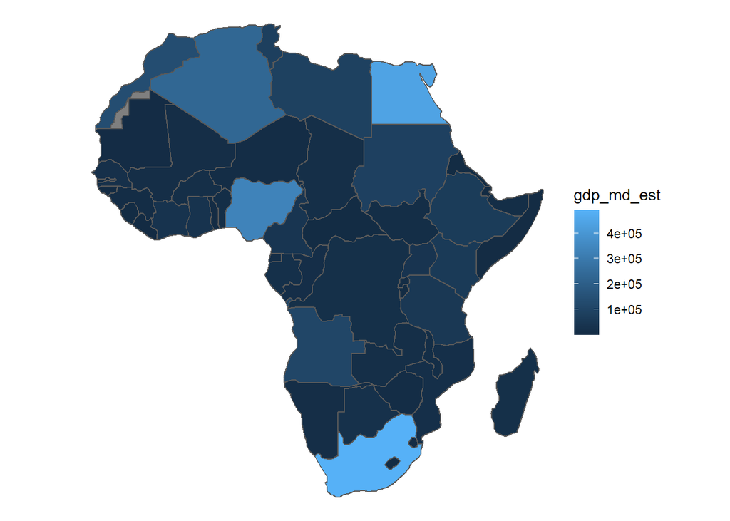

```r
gdp_map +
  theme_void()
```

The `ggthemes` package has even more themes to choose from, like `theme_economist()`, which is meant to make a graph in the style of *The Economist* magazine.

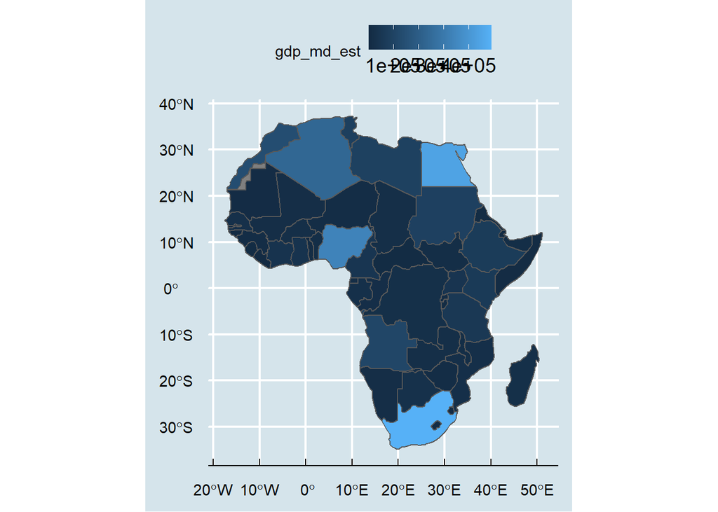

```r
gdp_map +
  theme_economist()
```

Or `theme_fivethirtyeight`, which is meant to make a graph look like the ones published by Nate Silver’s FiveThirtyEight website.

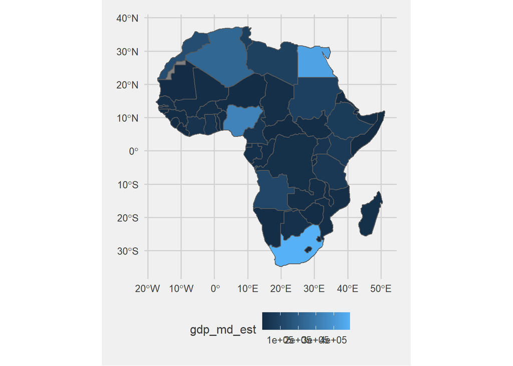

```r
gdp_map +
  theme_fivethirtyeight()
```

Again, most of these were designed for scatter plots and similar graphs. They might be less useful for maps. But one `ggthemes` theme that is useful for maps is `theme_map`. It looks a lot like `theme_void()`, but it places the legend on top of the map, in the bottom left corner, and makes the legend text a little smaller.

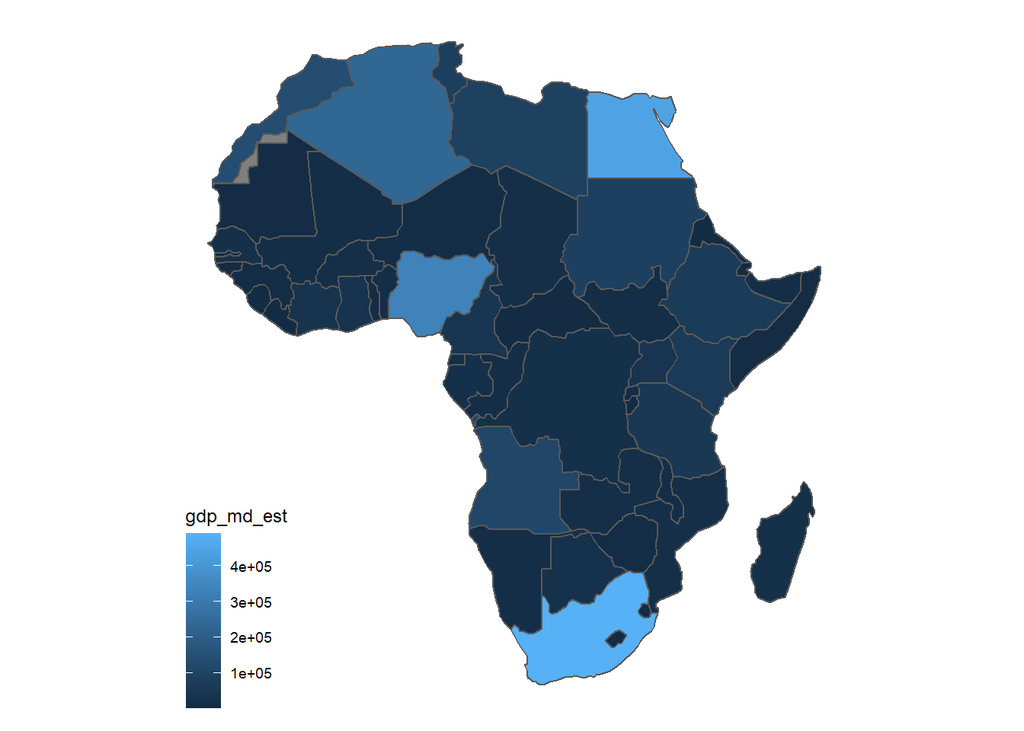

```r
gdp_map +
  theme_map()
```